# Stat542: Linear Regression

Fall 2022

## Load Data

The **Prostate data** can be found [[here](https://hastie.su.domains/ElemStatLearn/data.html)]. The data is to examine the correlation between the level of prostate-specific antigen and a number of clinical measures in men who were about to receive a radical prostatectomy.

- `lcavol`: log cancer volume
- `lweight`: log prostate weight
- `age`: in years
- `lbph`: log of the amount of benign prostatic hyperplasia
- `svi`: seminal vesicle invasion
- `lcp`: log of capsular penetration
- `gleason`: a numeric vector
- `pgg45`: percent of Gleason score 4 or 5
- `lpsa`: response

The first 8 columns are predictors; column 9 is the outcome/response. We do not use column 10, which indicates which 67 observations were used as the “training set” and which 30 as the test set, as described on page 48 in the ESL book.

```r
myData = read.table(file = "https://hastie.su.domains/ElemStatLearn/datasets/prostate.data", header = TRUE)
dim(myData)
```

```
[1] 97 10
```

```r
names(myData)
```

```
 [1] "lcavol"  "lweight" "age"     "lbph"    "svi"     "lcp"     "gleason"
 [8] "pgg45"   "lpsa"    "train"
```

Remove column 10 and run a quick summary of each column of the data. For convenience, we rename the response column with a generic name Y.

```r
myData = myData[, -10]
names(myData)[9] = 'Y'
summary(myData)
```

```
     lcavol           lweight           age             lbph
 Min.   :-1.3471   Min.   :2.375   Min.   :41.00   Min.   :-1.3863
 1st Qu.: 0.5128   1st Qu.:3.376   1st Qu.:60.00   1st Qu.:-1.3863
 Median : 1.4469   Median :3.623   Median :65.00   Median : 0.3001
 Mean   : 1.3500   Mean   :3.629   Mean   :63.87   Mean   : 0.1004
 3rd Qu.: 2.1270   3rd Qu.:3.876   3rd Qu.:68.00   3rd Qu.: 1.5581
 Max.   : 3.8210   Max.   :4.780   Max.   :79.00   Max.   : 2.3263
      svi              lcp             gleason          pgg45
 Min.   :0.0000   Min.   :-1.3863   Min.   :6.000   Min.   :  0.00
 1st Qu.:0.0000   1st Qu.:-1.3863   1st Qu.:6.000   1st Qu.:  0.00
 Median :0.0000   Median :-0.7985   Median :7.000   Median : 15.00
 Mean   :0.2165   Mean   :-0.1794   Mean   :6.753   Mean   : 24.38
 3rd Qu.:0.0000   3rd Qu.: 1.1787   3rd Qu.:7.000   3rd Qu.: 40.00
 Max.   :1.0000   Max.   : 2.9042   Max.   :9.000   Max.   :100.00
       Y
 Min.   :-0.4308
 1st Qu.: 1.7317
 Median : 2.5915
 Mean   : 2.4784
 3rd Qu.: 3.0564
 Max.   : 5.5829
```

Produce a pair-wise scatter plot. Caution: a big figure.

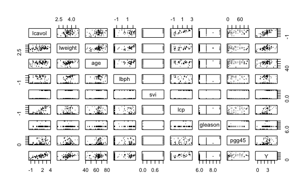

```r
pairs(myData, pch='.')
```

## Fit a Linear Model

Fit a linear regression model using all the predictors and print the summary of the LS results

```r
lmfit <-  lm(Y ~ ., data = myData)
summary(lmfit)
```

```
Call:
lm(formula = Y ~ ., data = myData)

Residuals:
     Min       1Q   Median       3Q      Max
-1.76644 -0.35510 -0.00328  0.38087  1.55770

Coefficients:
             Estimate Std. Error t value Pr(>|t|)
(Intercept)  0.181561   1.320568   0.137  0.89096
lcavol       0.564341   0.087833   6.425 6.55e-09 ***
lweight      0.622020   0.200897   3.096  0.00263 **
age         -0.021248   0.011084  -1.917  0.05848 .
lbph         0.096713   0.057913   1.670  0.09848 .
svi          0.761673   0.241176   3.158  0.00218 **
lcp         -0.106051   0.089868  -1.180  0.24115
gleason      0.049228   0.155341   0.317  0.75207
pgg45        0.004458   0.004365   1.021  0.31000
---
Signif. codes:  0 ‘***’ 0.001 ‘**’ 0.01 ‘*’ 0.05 ‘.’ 0.1 ‘ ’ 1

Residual standard error: 0.6995 on 88 degrees of freedom
Multiple R-squared:  0.6634,    Adjusted R-squared:  0.6328
F-statistic: 21.68 on 8 and 88 DF,  p-value: < 2.2e-16
```

Check what are returned by `lm` and learn how to retrieve those results.

```r
names(lmfit)  # What are returned by "lm"?
```

```
 [1] "coefficients"  "residuals"     "effects"       "rank"
 [5] "fitted.values" "assign"        "qr"            "df.residual"
 [9] "xlevels"       "call"          "terms"         "model"
```

```r
names(summary(lmfit)) # What are returned by the summary of lmfit
```

```
 [1] "call"          "terms"         "residuals"     "coefficients"
 [5] "aliased"       "sigma"         "df"            "r.squared"
 [9] "adj.r.squared" "fstatistic"    "cov.unscaled"
```

```r
# Regression coefficients including the intercept
lmfit$coef
lmfit$residuals[1]
length(lmfit$residuals)
```

Check the calculation for `Residual standard error` and `Multiple R-squared` in the summary output:

```r
n = dim(myData)[1]
p = dim(myData)[2] - 1
# Residual standard error
c(sqrt(sum(lmfit$residuals^2)/(n- p - 1)), summary(lmfit)$sigma)
# R-squared
c(1 - sum(lmfit$residuals^2)/(var(myData$Y)*(n-1)), summary(lmfit)$r.squared)
1 - var(lmfit$residuals)/var(myData$Y)
```

## Prediction

- **Method 1**: prepare the new obs as a matrix (or vector) and then use formula: newX * beta + beta0, where (beta0, beta) are LS coefficients.
- **Method 2**: prepare the new obs as a data frame with the same column names (for predictor) as `myData`, and then call the `predict` function.

Next we illustrate this with two new patients: one is 50 years old and the other is 70 years old; all other features take the median values of the 97 patients.

```r
apply(myData, 2, median)
newx1 = c(1.45, 3.62, 50, 0.30, 0, -0.80, 7, 15) #1st patient: age = 50
newx2 = newx1
newx2[3] = 70 #2nd patient: age = 70
newx = rbind(newx1, newx2)
newx %*% lmfit$coef[-1] + lmfit$coef[1]
```

To use the `predict` function, we need to prepare the new data matrix as a data frame with the same column names; of course, the new data frame does not need to include the response column.

```r
newdf = data.frame(newx)
names(newdf) = names(myData[, -dim(myData)[2]]) # assign col names after dropping the last col
```

An advantage of the `predict` function is that once columns have names, their order does not matter. So, let’s shuffle the columns of `newdf` and then predict. The result should be the same as what is returned by Method 1.

```r
newdf
newdf = newdf[, sample(1:dim(newdf)[2])]
newdf
predict(lmfit, newdata = newdf)
```

## Rank Deficiency

If the design matrix (including the intercept) is not of full rank, the coefficient vector returned by R will have some elements to be NA. A column has its LS estimate to be NA means that it can be written as a linear combination of some columns listed before it, that is, this is a redundant column.

**NA values do not mean errors**. It just means that in the LS fitting, R ignores the columns with NA coefficients. You can still use the fitted model to do prediction. The result should be the same as if you fit a linear regression model without those columns.

```r
## Add a fake column named "junk", which is a linear combination of the first two predictors
myData$junk <-  myData[, 1] + myData[, 2]
tmp.lm <-  lm(Y ~ ., myData)
summary(tmp.lm)

## The fitted values (for the first 3 obs) are the same.
tmp.lm$fitted[1:3]
lmfit$fitted[1:3]

## drop the "junk" column
myData = myData[, !names(myData) == 'junk' ]
```

## Training vs Test Errors

For linear regression models, when we add more and more variables, the training error (e.g., RSS or MSE) is always decreasing, but the test error (prediction error on an independent test data) is not necessary decreasing. We illustrate this by randomly dividing the data into training (60%) and test (40%) and then reporting the training/test errors when we sequentially add more and more predictors.

```r
n <- dim(myData)[1] # sample size
p <-  dim(myData)[2] - 1 # number of non-intercept predictors

ntrain <-  round(n*0.6)
train.id <-  sample(1:n, ntrain)
train.MSE <-  rep(0, p)
test.MSE <-  rep(0, p)

for(i in 1:p){
  myfit <-  lm(Y ~ ., myData[train.id, c(1:i, (p+1))])
  train.Y <-  myData[train.id, (p+1)]
  train.Y.pred <-  myfit$fitted
  train.MSE[i] <-  mean((train.Y - train.Y.pred)^2)

  test.Y <-  myData[-train.id, (p+1)]
  test.Y.pred <-  predict(myfit, newdata = myData[-train.id, ])
  test.MSE[i] <-  mean((test.Y - test.Y.pred)^2)
}

## type="n": don't plot; just set the plotting region
  plot(c(1, p), range(train.MSE, test.MSE), type="n", xlab="# of variables", ylab="MSE")
  points(train.MSE, col = "blue", pch = 1)
```

```r
  lines(train.MSE, col = "blue", pch = 1)
  points(test.MSE, col = "red", pch = 2)
```

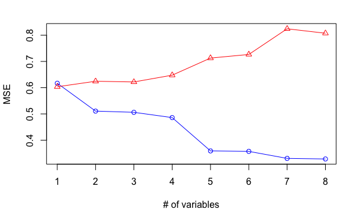

```r
  lines(test.MSE, col = "red", pch = 2)
```

You can run the code above multiple times.

- In most cases, the blue line is below the red line (i.e., training error is better than test error), but sometimes, the red line could be below the blue line (i.e., test error is even better than the training error; this is possible due to randomness).
- In each iteration, you would see the blue line is always monotonically decreasing, but red line is not necessarily decreasing. Check the differences between the adjacent terms, which should be always negative for the blue line, but could have some positive terms for the red line.

```r
diff(train.MSE) ## always negative
diff(test.MSE)  ## not always negative
```

## Interpret LS Coefficients

How to interpret LS coefficients? For example, the coefficient for variable `age` measures the average change of the response per year, **with all other predictors held fixed**.

```r
summary(lm(Y~ age, myData))
round(cor(myData), dig=2)
```

## Partial Regression Coef

Check how to retrieve the LS coefficient for `age` using Algorithm 3.1

```r
y.star <-  lm(Y ~ ., data = subset(myData, select = -age))$res
age.star <-  lm(age ~ ., data = subset(myData, select = -Y))$res
tmpfit <-  lm(y.star ~ age.star)
```

The LS coefficient for `age` (from `lmfit`) is the same as the one from `tmpfit`. The residuals from the two LS models are also the same.

```r
tmpfit$coef
```

```
  (Intercept)      age.star
 4.509043e-17 -2.124819e-02
```

```r
sum((lmfit$res - tmpfit$res)^2)
```

```
[1] 1.694534e-29
```

## F-test

Test a single predictor (in this case, F-test = t-test).

```r
lmfit0 <- lm(Y ~ ., data = subset(myData, select = -age))
anova(lmfit0, lmfit)
```

Test multiple predictors.

```r
lmfit0 <- lm(Y ~ ., data = myData[, -c(1:3)])
anova(lmfit0, lmfit)
```

## Collinearity

Check the Car Seat Position Data from faraway package.

Car drivers like to adjust the seat position for their own comfort. Car designers would find it helpful to know how different drivers will position the seat depending on their size and age. Researchers at the [HuMoSim laboratory](http://humosim.org/) at the University of Michigan collected data on 38 drivers.

- Age:
- Weight:
- HtShoes: height with shoes in cm
- Ht: height without shoes in cm
- Seated: seated height in cm
- Arm: lower arm length in cm
- Thigh: thigh length in cm
- Leg: lower leg length in cm
- hipcenter: horizontal distance of the midpoint of the hips from a fixed location in the car in mm

The researchers were interested in determining if a relationship exists between hipcenter and the other variables. Due to the high correlations among the predictors, we see high R-square, significant overall F-test, but no individual variables are significant.

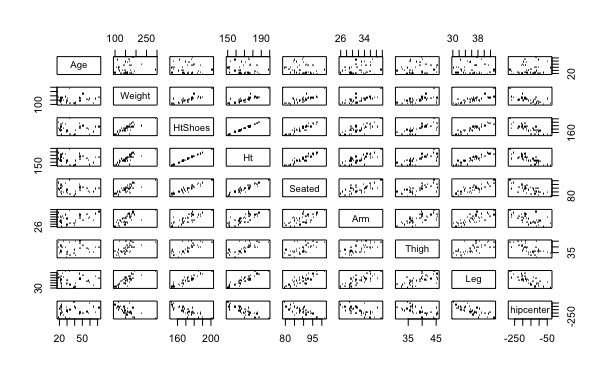

```r
library(faraway)
data(seatpos)
pairs(seatpos, pch = ".")
```

```r
summary(lm(hipcenter ~ . , data=seatpos))
```

```
Call:
lm(formula = hipcenter ~ ., data = seatpos)

Residuals:
    Min      1Q  Median      3Q     Max
-73.827 -22.833  -3.678  25.017  62.337

Coefficients:
             Estimate Std. Error t value Pr(>|t|)
(Intercept) 436.43213  166.57162   2.620   0.0138 *
Age           0.77572    0.57033   1.360   0.1843
Weight        0.02631    0.33097   0.080   0.9372
HtShoes      -2.69241    9.75304  -0.276   0.7845
Ht            0.60134   10.12987   0.059   0.9531
Seated        0.53375    3.76189   0.142   0.8882
Arm          -1.32807    3.90020  -0.341   0.7359
Thigh        -1.14312    2.66002  -0.430   0.6706
Leg          -6.43905    4.71386  -1.366   0.1824
---
Signif. codes:  0 ‘***’ 0.001 ‘**’ 0.01 ‘*’ 0.05 ‘.’ 0.1 ‘ ’ 1

Residual standard error: 37.72 on 29 degrees of freedom
Multiple R-squared:  0.6866,    Adjusted R-squared:  0.6001
F-statistic:  7.94 on 8 and 29 DF,  p-value: 1.306e-05
```

```r
## check pairwise correlation
round(cor(seatpos), dig=2)
```

```
            Age Weight HtShoes    Ht Seated   Arm Thigh   Leg hipcenter
Age        1.00   0.08   -0.08 -0.09  -0.17  0.36  0.09 -0.04      0.21
Weight     0.08   1.00    0.83  0.83   0.78  0.70  0.57  0.78     -0.64
HtShoes   -0.08   0.83    1.00  1.00   0.93  0.75  0.72  0.91     -0.80
Ht        -0.09   0.83    1.00  1.00   0.93  0.75  0.73  0.91     -0.80
Seated    -0.17   0.78    0.93  0.93   1.00  0.63  0.61  0.81     -0.73
Arm        0.36   0.70    0.75  0.75   0.63  1.00  0.67  0.75     -0.59
Thigh      0.09   0.57    0.72  0.73   0.61  0.67  1.00  0.65     -0.59
Leg       -0.04   0.78    0.91  0.91   0.81  0.75  0.65  1.00     -0.79
hipcenter  0.21  -0.64   -0.80 -0.80  -0.73 -0.59 -0.59 -0.79      1.00
```

If we remove some (almost) redundant variables, the LS results make much more sense.

```r
summary(lm(hipcenter ~ Age + Weight + Ht + Seated, data=seatpos))
summary(lm(hipcenter ~ Ht, data=seatpos))
```